# Intro to Infectious Diseases

Showing some neat features of R!

Author

Affiliation

[Jesús N. Pinto-Ledezma](https://jesusnpl.github.io)

[Ecology, Evolution & Behavior, University of Minnesota Biodiversity Science - EBB 3534-5534](https://github.com/jesusNPL/BiodiversityScience)

Published

March 8, 2024

**Note**

Today we will have one more lab and will explore basic aspects of models for Spread of Disease or Compartmental models that are used to simplify the mathematical modeling of infectious diseases, more specifically, we will explore the basic $SIR$ (Susceptible, Infectious, Recovered) model that is used to predict disease spreads, the total number of infected subjects of the duration of a pandemic. To do so, we will use real data obtained from the [**Centers for Disease Control and Prevention**](https://www.cdc.gov) that reports aggregate counts of COVID-19 at State level for the United States.

We can get information about **herd immunity** in an amazing paper published in the **American Journal of Preventive Medicine**. The paper entitles Vaccine Efficacy Needed for a COVID-19 Coronavirus Vaccine to Prevent or Stop an Epidemic as the Sole Intervention and was written by Bartsch et al. (2020). Another nice paper to understand the **herd immunity** concept was published in **Current Biology** by Ashby & Best (2021), you can get access to that conceptual paper by clicking HERE.

# 1 Set up your data and your working directory

To do this laboratory you will need to have a set of R packages. Install the following packages:

```r
# Package vector names
packages <- c("coronavirus", "deSolve", "lubridate", "scales", "PrettyCols")
```

**Function install.packages()**

You can use the function **install.packages()** to install the packages.

If you don’t want to install the packages one by one, you can use the next command.

```r
# Install packages not yet installed
installed_packages <- packages %in% rownames(installed.packages())

if (any(installed_packages == FALSE)) {
  install.packages(packages[!installed_packages], dependencies = TRUE)
}
```

This command, will, first, check if you already the packages installed, then if a package is not installed in your computer, will install it.

Load installed packages:

```r
library(tidyverse)
library(lubridate)
library(coronavirus)
library(PrettyCols)
library(scales)
library(deSolve)
```

Double-check your working directory.

**Function getwd()**

You can use the function **getwd()** to get the current working directory.

# 2 Data exploration

First we will explore the data for the **COVID-19** for different countries. To do that we will get data at global scale using the amazing R package {**coronavirus**} that provides a daily summary of **COVID-19** cases by country obtained from the [Johns Hopkins University Center for Systems Science and Engineering (JHU CCSE) Coronavirus](https://systems.jhu.edu/research/public-health/ncov/).

```r
data("coronavirus")

glimpse(coronavirus)
```

```
Rows: 973,836
Columns: 15
$ date           <date> 2020-01-22, 2020-01-23, 2020-01-24, 2020-01-25, 2020-0…
$ province       <chr> "Alberta", "Alberta", "Alberta", "Alberta", "Alberta", …
$ country        <chr> "Canada", "Canada", "Canada", "Canada", "Canada", "Cana…
$ lat            <dbl> 53.9333, 53.9333, 53.9333, 53.9333, 53.9333, 53.9333, 5…
$ long           <dbl> -116.5765, -116.5765, -116.5765, -116.5765, -116.5765, …
$ type           <chr> "confirmed", "confirmed", "confirmed", "confirmed", "co…
$ cases          <dbl> 0, 0, 0, 0, 0, 0, 0, 0, 0, 0, 0, 0, 0, 0, 0, 0, 0, 0, 0…
$ uid            <dbl> 12401, 12401, 12401, 12401, 12401, 12401, 12401, 12401,…
$ iso2           <chr> "CA", "CA", "CA", "CA", "CA", "CA", "CA", "CA", "CA", "…
$ iso3           <chr> "CAN", "CAN", "CAN", "CAN", "CAN", "CAN", "CAN", "CAN",…
$ code3          <dbl> 124, 124, 124, 124, 124, 124, 124, 124, 124, 124, 124, …
$ combined_key   <chr> "Alberta, Canada", "Alberta, Canada", "Alberta, Canada"…
$ population     <dbl> 4413146, 4413146, 4413146, 4413146, 4413146, 4413146, 4…
$ continent_name <chr> "North America", "North America", "North America", "Nor…
$ continent_code <chr> "NA", "NA", "NA", "NA", "NA", "NA", "NA", "NA", "NA", "…
```

**The package {tidylog}**

We are using **tidyverse** for almost everything in the lab sessions. If you want to know what we are really doing, you can install and load the R package named {tidylog}. This package will print in your console the different operations within the pipes.

**IMPORTANT:** JHU Has Stopped Collecting Data As Of **03 / 10 / 2023**

If you received an error while uploading the coronavirus dataset, use the next code. If not, please skip this lines.

```r
githubURL <- "https://github.com/jesusNPL/BiodiversityScience/raw/master/Spring2024/Lab_3_Infectious_diseases/data/coronavirus.RData"

load(url(githubURL))

glimpse(coronavirus)
```

Let’s start exploring the total numbers of confirmed cases by country.

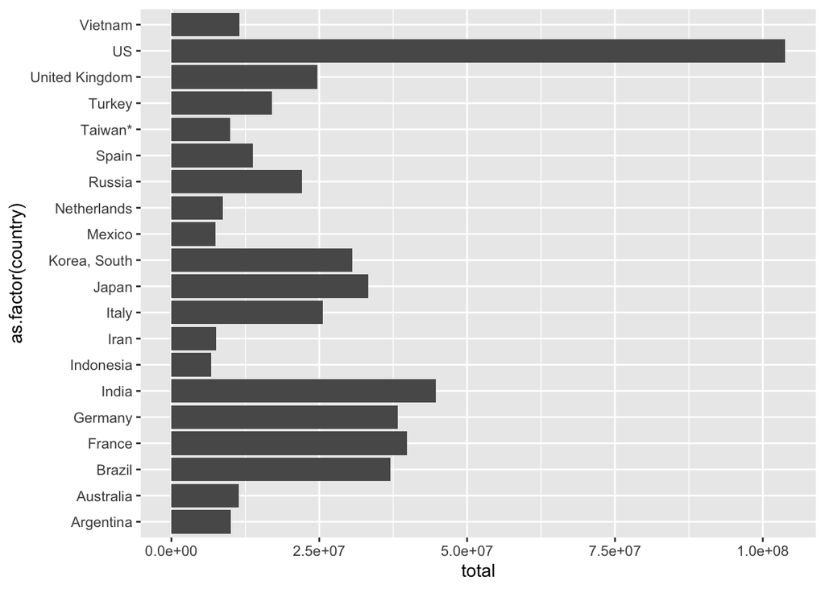

```r
# Get top confirmed cases by country
coronavirus %>%
  filter(type == "confirmed") %>% # filter confirmed cases
  group_by(country) %>% # group cases by country
  summarise(total = sum(cases)) %>% # sum all cases
  arrange(-total) %>% # select the countries with more cases
  head(20) %>%
  ggplot(aes(y = as.factor(country), x = total)) +
  geom_bar(stat = "identity")
```

Informative but not good looking… let’s play a bit more!

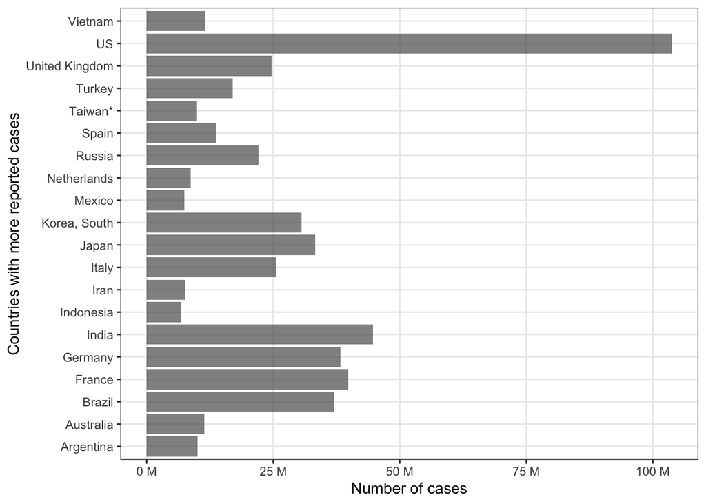

```r
# Aux function for visualization
theme_biosci <- function() {
  theme_bw() +
    theme(panel.grid.minor = element_blank(),
          plot.background = element_rect(fill = "white", color = NA),
          strip.background = element_rect(fill = "grey80", color = NA),
          legend.title = element_text(face = "bold", size = 25),
          legend.text = element_text(size = 20))
}

# Get top confirmed cases by country
coronavirus %>%
  filter(type == "confirmed") %>%
  group_by(country) %>%
  summarise(total = sum(cases)) %>%
  arrange(desc(total)) %>%
  head(20) %>%
  ggplot(aes(y = as.factor(country), x = total)) +
  geom_bar(stat = "identity", alpha = 0.7) +
  scale_x_continuous(labels = scales::label_number(suffix = " M",
                                                   scale = 1e-6)) +
  labs(x = "Number of cases",
       y = "Countries with more reported cases") +
  theme_biosci()
```

Much, much better!

*What about the 20 countries with less number of reported cases?*

```r
# Get countries with less confirmed cases by country
coronavirus %>%
  filter(type == "confirmed") %>%
  group_by(country) %>%
  summarise(total = sum(cases)) %>%
  arrange(desc(total)) %>%
  tail(20)
```

```
# A tibble: 20 × 2
   country               total
   <chr>                 <dbl>
 1 Niger                  9508
 2 Antigua and Barbuda    9106
 3 Comoros                9008
 4 Guinea-Bissau          8960
 5 Liberia                8090
 6 Sierra Leone           7760
 7 Chad                   7679
 8 Saint Kitts and Nevis  6597
 9 Sao Tome and Principe  6281
10 Palau                  5991
11 Nauru                  5247
12 Kiribati               5014
13 Tuvalu                 2805
14 Summer Olympics 2020    865
15 Diamond Princess        712
16 Winter Olympics 2022    535
17 Holy See                 29
18 Antarctica               11
19 MS Zaandam                9
20 Korea, North              1
```

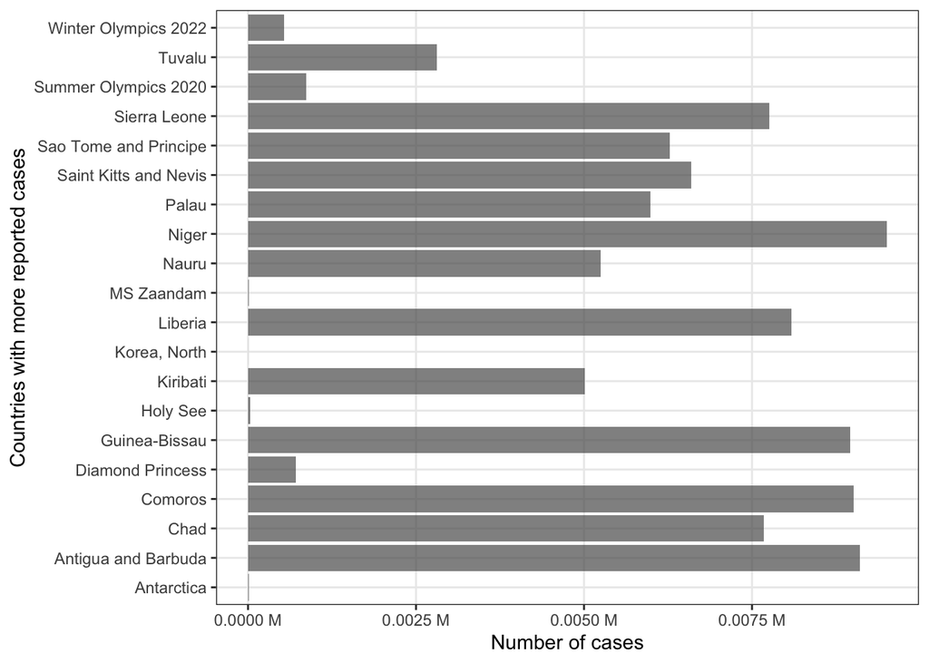

```r
# Plot countries with less confirmed cases by country
coronavirus %>%
  filter(type == "confirmed") %>%
  group_by(country) %>%
  summarise(total = sum(cases)) %>%
  arrange(desc(total)) %>%
  tail(20) %>%
  ggplot(aes(y = as.factor(country), x = total)) +
  geom_bar(stat = "identity", alpha = 0.7) +
  scale_x_continuous(labels = scales::label_number(suffix = " M",
                                                   scale = 1e-6)) +
  labs(x = "Number of cases",
       y = "Countries with more reported cases") +
  theme_biosci()
```

We can also omit the Olympics and plot the results for actual countries.

```r
## Get countries with less confirmed cases by country
coronavirus %>%
  filter(type == "confirmed") %>%
  group_by(country) %>%
  summarise(total = sum(cases)) %>%
  arrange(desc(total)) %>%
  filter(country != "Summer Olympics 2020") %>%
  filter(country != "Winter Olympics 2022") %>%
  tail(20)
```

```
# A tibble: 20 × 2
   country                          total
   <chr>                            <dbl>
 1 Eritrea                          10189
 2 Saint Vincent and the Grenadines  9589
 3 Niger                             9508
 4 Antigua and Barbuda               9106
 5 Comoros                           9008
 6 Guinea-Bissau                     8960
 7 Liberia                           8090
 8 Sierra Leone                      7760
 9 Chad                              7679
10 Saint Kitts and Nevis             6597
11 Sao Tome and Principe             6281
12 Palau                             5991
13 Nauru                             5247
14 Kiribati                          5014
15 Tuvalu                            2805
16 Diamond Princess                   712
17 Holy See                            29
18 Antarctica                          11
19 MS Zaandam                           9
20 Korea, North                         1
```

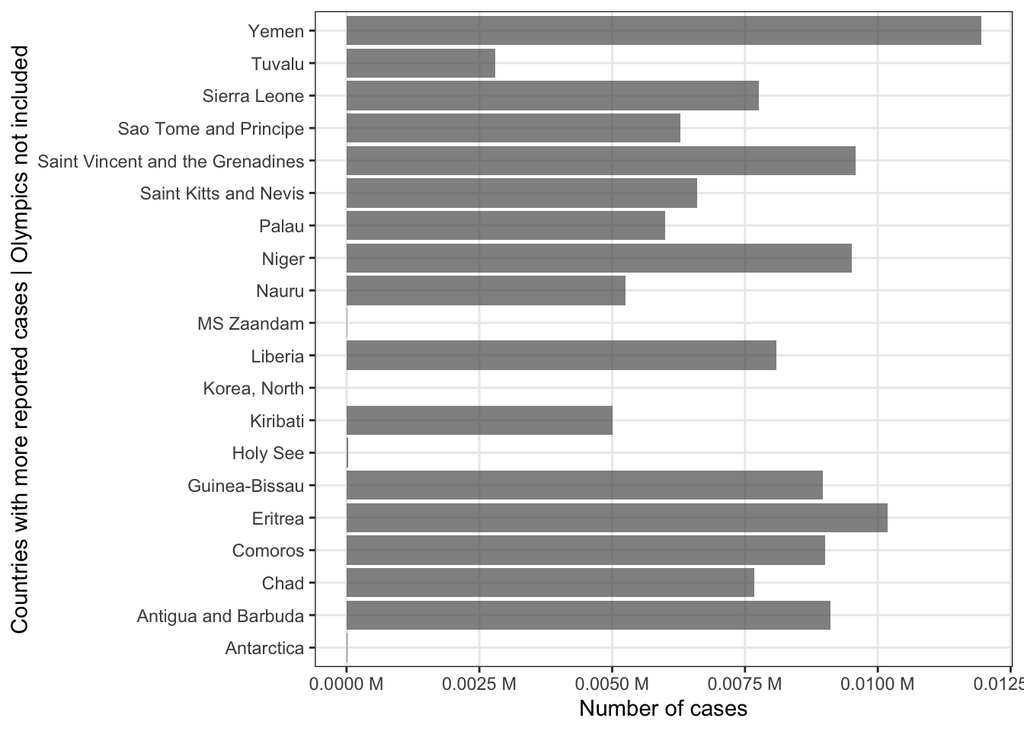

```r
# Plot countries with less confirmed cases by country
coronavirus %>%
  filter(type == "confirmed") %>%
  group_by(country) %>%
  summarise(total = sum(cases)) %>%
  arrange(desc(total)) %>%
  filter(country != "Summer Olympics 2020") %>%
  filter(country != "Winter Olympics 2022") %>%
  filter(country != "Diamond Princess") %>%
  tail(20) %>%
  ggplot(aes(y = as.factor(country), x = total)) +
  geom_bar(stat = "identity", alpha = 0.7) +
  scale_x_continuous(labels = scales::label_number(suffix = " M",
                                                   scale = 1e-6)) +
  labs(x = "Number of cases",
       y = "Countries with more reported cases | Olympics not included") +
  theme_biosci()
```

*Which countries reported fewer cases of COVID-19?*

**Answer:** The top five countries/territories with less reported cases were Diamond Princess, Holy See, Antarctica, MS Zaandam, and North Korea. Note that [Diamond Princess](https://www.princess.com/en-us/ships-and-experience/ships/di-diamond-princess) and [MS Zaandam](https://www.hollandamerica.com/en/us/cruise-ships/zaandam/7) are cruise ships.

```r
## Get countries with less confirmed cases by country
coronavirus %>%
  filter(type == "confirmed") %>%
  group_by(country) %>%
  summarise(total = sum(cases)) %>%
  arrange(desc(total)) %>%
  filter(country != "Summer Olympics 2020") %>%
  filter(country != "Winter Olympics 2022") %>%
  tail(5)
```

```
# A tibble: 5 × 2
  country          total
  <chr>            <dbl>
1 Diamond Princess   712
2 Holy See            29
3 Antarctica          11
4 MS Zaandam           9
5 Korea, North         1
```

*What about the number of reported recovered cases?*

**Answer:** The countries with more recovery cases were India, Brazil, Russia, Turkey and Argentina.

```r
## Get countries with more recovery cases
coronavirus %>%
  filter(type == "recovery") %>%
  group_by(country) %>%
  summarise(total = sum(cases)) %>%
  arrange(desc(total)) %>%
  filter(country != "Summer Olympics 2020") %>%
  filter(country != "Winter Olympics 2022") %>%
  filter(country != "Diamond Princess") %>%
  filter(country != "MS Zaandam") %>%
  head(20)
```

```
# A tibble: 20 × 2
   country         total
   <chr>           <dbl>
 1 India        30974748
 2 Brazil       17771228
 3 Russia        5609682
 4 Turkey        5478185
 5 Argentina     4615834
 6 Colombia      4615354
 7 Italy         4144608
 8 Germany       3659260
 9 Iran          3444798
10 Indonesia     2907920
11 Poland        2653981
12 Mexico        2270427
13 South Africa  2258603
14 Ukraine       2258433
15 Peru          2086086
16 Czechia       1641321
17 Chile         1575377
18 Philippines   1528422
19 Iraq          1494760
20 Canada        1405971
```

Plot the top 20 with more reported cases of recovery.

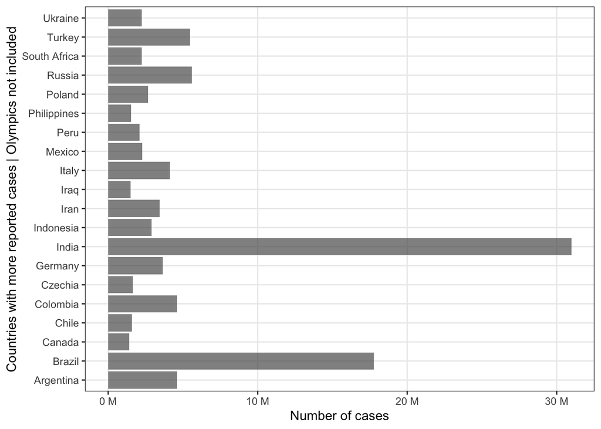

```r
coronavirus %>%
  filter(type == "recovery") %>%
  group_by(country) %>%
  summarise(total = sum(cases)) %>%
  arrange(desc(total)) %>%
  filter(country != "Summer Olympics 2020") %>%
  filter(country != "Winter Olympics 2022") %>%
  filter(country != "Diamond Princess") %>%
  filter(country != "MS Zaandam") %>%
  head(20) %>%
  ggplot(aes(y = as.factor(country), x = total)) +
  geom_bar(stat = "identity", alpha = 0.7) +
  scale_x_continuous(labels = scales::label_number(suffix = " M",
                                                   scale = 1e-6)) +
  labs(x = "Number of cases",
       y = "Countries with more reported cases | Olympics not included") +
  theme_biosci()
```

```r
## Get countries with more recovery cases
coronavirus %>%
  filter(type == "recovery") %>%
  group_by(country) %>%
  summarise(total = sum(cases)) %>%
  arrange(desc(total)) %>%
  filter(country != "Summer Olympics 2020") %>%
  filter(country != "Winter Olympics 2022") %>%
  filter(country != "Diamond Princess") %>%
  filter(country != "MS Zaandam") %>%
  tail(20)
```

```
# A tibble: 20 × 2
   country          total
   <chr>            <dbl>
 1 Dominica           209
 2 Tanzania           183
 3 Grenada            161
 4 Holy See            27
 5 Solomon Islands     20
 6 Marshall Islands     4
 7 Samoa                3
 8 Vanuatu              3
 9 Micronesia           1
10 Antarctica           0
11 Belgium              0
12 Kiribati             0
13 Korea, North         0
14 Nauru                0
15 Palau                0
16 Serbia               0
17 Sweden               0
18 Tonga                0
19 Tuvalu               0
20 US                   0
```

*How do feel about that?*

**Answer:** The data available is very variable and may not be completely accurate. As such, we should take care in interpreting this information.

By quickly exploring the coronavirus dataset we can see that the United States is the country with more reported cases, not new information is added to our current knowledge, however, we can learn more about the COVID-19 dynamics in the US by looking at its changes over time–you can select any other country if you wish.

```r
coronavirus_us <- coronavirus %>%
  filter(country == "US") %>%
  arrange(desc(date)) # sort the data according dates
```

If we look at the US coronavirus data it contains information of the number of recovers (**R**), the number of new cases (**I**) and the the deaths. Let’s isolate those data and inspect if there are some trends.

```r
head(coronavirus)
```

```
        date province country     lat      long      type cases   uid iso2 iso3
1 2020-01-22  Alberta  Canada 53.9333 -116.5765 confirmed     0 12401   CA  CAN
2 2020-01-23  Alberta  Canada 53.9333 -116.5765 confirmed     0 12401   CA  CAN
3 2020-01-24  Alberta  Canada 53.9333 -116.5765 confirmed     0 12401   CA  CAN
4 2020-01-25  Alberta  Canada 53.9333 -116.5765 confirmed     0 12401   CA  CAN
5 2020-01-26  Alberta  Canada 53.9333 -116.5765 confirmed     0 12401   CA  CAN
6 2020-01-27  Alberta  Canada 53.9333 -116.5765 confirmed     0 12401   CA  CAN
  code3    combined_key population continent_name continent_code
1   124 Alberta, Canada    4413146  North America             NA
2   124 Alberta, Canada    4413146  North America             NA
3   124 Alberta, Canada    4413146  North America             NA
4   124 Alberta, Canada    4413146  North America             NA
5   124 Alberta, Canada    4413146  North America             NA
6   124 Alberta, Canada    4413146  North America             NA
```

```r
infected_us <- coronavirus %>%
  filter(country == "US") %>%
  arrange(desc(date)) %>%
  filter(type == "confirmed")

deaths_us <- coronavirus %>%
  filter(country == "US") %>%
  arrange(desc(date)) %>%
  filter(type == "death")

recovered_us <- coronavirus %>%
  filter(country == "US") %>%
  arrange(desc(date)) %>%
  filter(type == "recovery")

head(infected_us)
```

```
        date province country lat long      type cases uid iso2 iso3 code3
1 2023-03-09     <NA>      US  40 -100 confirmed 46931 840   US  USA   840
2 2023-03-08     <NA>      US  40 -100 confirmed 64861 840   US  USA   840
3 2023-03-07     <NA>      US  40 -100 confirmed 35371 840   US  USA   840
4 2023-03-06     <NA>      US  40 -100 confirmed  8564 840   US  USA   840
5 2023-03-05     <NA>      US  40 -100 confirmed -3862 840   US  USA   840
6 2023-03-04     <NA>      US  40 -100 confirmed  2147 840   US  USA   840
  combined_key population continent_name continent_code
1           US  329466283  North America             NA
2           US  329466283  North America             NA
3           US  329466283  North America             NA
4           US  329466283  North America             NA
5           US  329466283  North America             NA
6           US  329466283  North America             NA
```

Let’s plot the new cases.

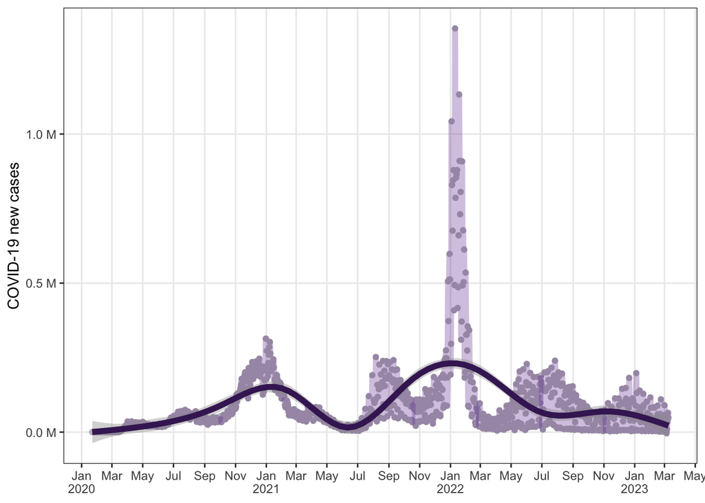

```r
coronavirus_us %>%
  filter(type == "confirmed") %>%
  ggplot(aes(x = as.POSIXct(date), y = cases)) +
  geom_point(color = "gray") +
  labs(x = NULL, y = "COVID-19 new cases") +
  geom_line(mapping = aes(x = as.POSIXct(date)),
            linewidth = 2,
            colour = alpha(PrettyCols::prettycols("Purples")[4],
                           0.3)) +
  geom_smooth(colour = PrettyCols::prettycols("Purples")[1],
              linewidth = 2) +
  scale_y_continuous(labels = scales::label_number(suffix = " M",
                                                   scale = 1e-6)) +
  scale_x_datetime(date_breaks = "2 month",
                   labels = scales::label_date_short()) +
  theme_biosci()
```

*How do you feel about that?*

**Answer:** These results are interesting as we can see infectious disease dynamics in the United States.

*Please explain the trend temporally; in other words, do the spikes in the number of cases match the US holidays?*

**Answer:** By looking at the trend, yes, the peaks match with the US national holidays or vacation periods. Interestingly, the highest peak of reported cases was between the end of December 2021 and mid-January 2022.

*What about the number of deaths and the number of recovered people?*

**Answer:** By plotting the number of recovery cases over time, we can see a continuous increase between March 2020 and December 2020. However, since January 2021, the reported recovery cases have been zero.

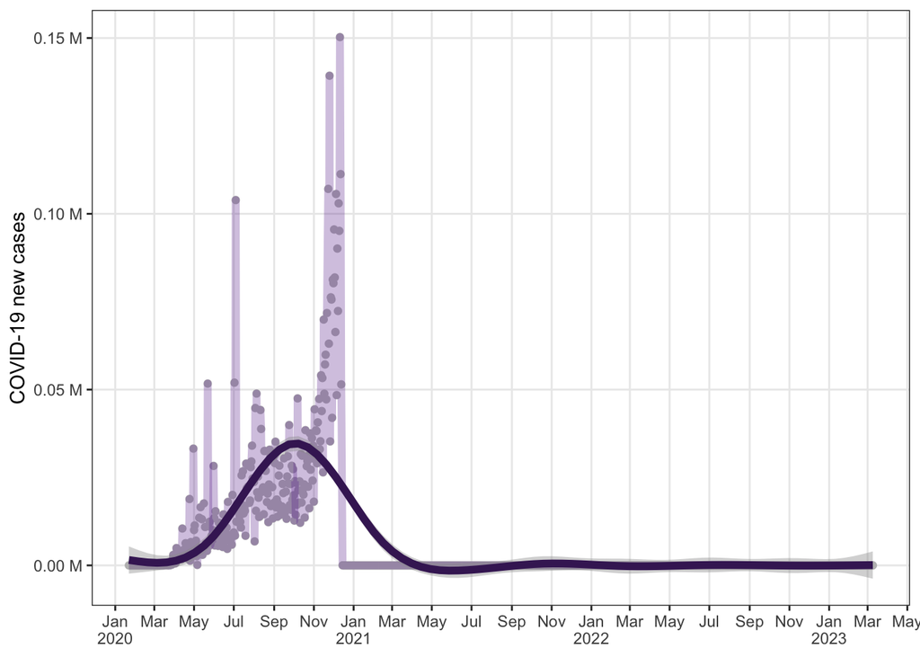

```r
coronavirus_us %>%
  filter(type == "recovery") %>%
  filter(cases >= 0) %>%
  ggplot(aes(x = as.POSIXct(date), y = cases)) +
  geom_point(color = "gray") +
  labs(x = NULL, y = "COVID-19 new cases") +
  geom_line(mapping = aes(x = as.POSIXct(date)),
            linewidth = 2,
            colour = alpha(PrettyCols::prettycols("Purples")[4],
                           0.3)) +
  geom_smooth(colour = PrettyCols::prettycols("Purples")[1],
              linewidth = 2) +
  scale_y_continuous(labels = scales::label_number(suffix = " M",
                                                   scale = 1e-6)) +
  scale_x_datetime(date_breaks = "2 month",
                   labels = scales::label_date_short()) +
  theme_biosci()
```

# 3 SIR model

## 3.1 Data preparation

The first step to build our first *SIR* model is to get data of a disease, well, we already have data of COVID-19 for each country in the world, however, as this dataset is at country level we probably will be missing some relevant information that occurs only at local scale, i.e., by States. In this sense, we will use data from the [**Centers for Disease Control and Prevention**](https://www.cdc.gov) that reports aggregate counts of COVID-19 at State level within the United States, how good is that? Okay, let’s go for it!

```r
githubURL <-
  "https://github.com/jesusNPL/BiodiversityScience/raw/master/Spring2024/Lab_3_Infectious_diseases/data/covidUS.RData"

load(url(githubURL))

# Explore the content
glimpse(covid_us)
```

```
Rows: 60,060
Columns: 15
$ submission_date <chr> "03/11/2021", "12/01/2021", "01/02/2022", "11/22/2021"…
$ state           <chr> "KS", "ND", "AS", "AL", "AK", "RMI", "ND", "PR", "PW",…
$ tot_cases       <int> 297229, 163565, 11, 841461, 251425, 0, 173, 173967, 0,…
$ conf_cases      <int> 241035, 135705, NA, 620483, NA, 0, NA, 144788, NA, NA,…
$ prob_cases      <int> 56194, 27860, NA, 220978, NA, 0, NA, 29179, NA, NA, 0,…
$ new_case        <int> 0, 589, 0, 703, 0, 0, 14, 667, 0, 1509, 0, 28, 2293, 5…
$ pnew_case       <int> 0, 220, 0, 357, 0, 0, NA, 274, 0, 0, 0, 5, 552, 1266, …
$ tot_death       <int> 4851, 1907, 0, 16377, 1252, 0, 3, 2911, 0, 8318, 3787,…
$ conf_death      <int> NA, NA, NA, 12727, NA, 0, NA, 2482, NA, NA, 3635, 1601…
$ prob_death      <int> NA, NA, NA, 3650, NA, 0, NA, 429, NA, NA, 152, 366, 0,…
$ new_death       <int> 0, 9, 0, 7, 0, 0, 0, 8, 0, 6, 0, 0, 0, 8, 0, 4, 0, 0, …
$ pnew_death      <int> 0, 0, 0, 3, 0, 0, NA, 3, 0, 0, 0, 0, 0, -1, 0, 0, 0, 0…
$ created_at      <chr> "03/12/2021 03:20:13 PM", "12/02/2021 02:35:20 PM", "0…
$ consent_cases   <chr> "Agree", "Agree", "", "Agree", "N/A", "Agree", "Agree"…
$ consent_deaths  <chr> "N/A", "Not agree", "", "Agree", "N/A", "Agree", "Not …
```

Let’s explore the data and clean it little bit.

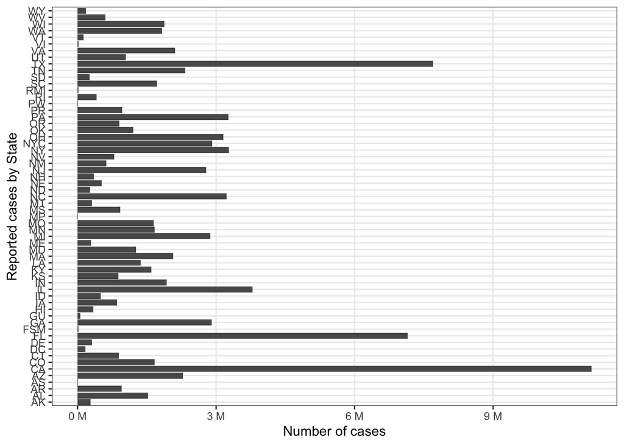

```r
covid_us %>%
  arrange(state) %>%
  drop_na(tot_cases) %>%
  group_by(state) %>% # group cases by state
  summarise(total = sum(new_case)) %>% # sum all cases
  ggplot(aes(y = state, x = total)) +
  geom_bar(stat = "identity") +
  labs(x = "Number of cases", y = "Reported cases by State") +
  scale_x_continuous(labels = scales::label_number(suffix = " M", scale = 1e-6)) +
  theme_biosci()
```

Let’s reformat the dates and order the data in an ascending order.

```r
covid_us <- covid_us %>%
  mutate(Date = submission_date) %>%
  mutate(Date = mdy(Date)) %>%
  select(Date, everything()) %>%
  separate(submission_date, sep = "/", into = c("month", "day", "year"))

# Sort the data in an increasing order
covid_us <- covid_us[order(covid_us$Date), ]

head(covid_us)
```

```
           Date month day year state tot_cases conf_cases prob_cases new_case
498  2020-01-22    01  22 2020    ND         0         NA         NA        0
697  2020-01-22    01  22 2020    MP         0          0          0        0
868  2020-01-22    01  22 2020    OH         0         NA         NA        0
2153 2020-01-22    01  22 2020    GA         0         NA         NA        0
3007 2020-01-22    01  22 2020    PW         0         NA         NA        0
3726 2020-01-22    01  22 2020    AL         0          0          0        0
     pnew_case tot_death conf_death prob_death new_death pnew_death
498         NA         0         NA         NA         0         NA
697          0         0          0          0         0          0
868         NA         0         NA         NA         0         NA
2153        NA         0         NA         NA         0         NA
3007        NA         0         NA         NA         0         NA
3726         0         0          0          0         0          0
                 created_at consent_cases consent_deaths
498  03/26/2020 04:22:39 PM         Agree      Not agree
697  01/24/2020 12:00:00 AM         Agree          Agree
868  03/26/2020 04:22:39 PM         Agree          Agree
2153 03/26/2020 04:22:39 PM         Agree          Agree
3007 03/26/2020 04:22:39 PM
3726 01/22/2020 12:00:00 AM         Agree          Agree
```

As we can see there are a lot of **NA** values in the dataset, these NA values are because there were no cases reported in the US in the first two months of the 2020.

The data is still very broad, let’s select data for the State of Minnesota.

```r
covid_mn <- covid_us %>%
  filter(state == "MN")

head(covid_mn)
```

```
        Date month day year state tot_cases conf_cases prob_cases new_case
1 2020-01-22    01  22 2020    MN         0         NA         NA        0
2 2020-01-23    01  23 2020    MN         0         NA         NA        0
3 2020-01-24    01  24 2020    MN         0         NA         NA        0
4 2020-01-25    01  25 2020    MN         0         NA         NA        0
5 2020-01-26    01  26 2020    MN         0         NA         NA        0
6 2020-01-27    01  27 2020    MN         0         NA         NA        0
  pnew_case tot_death conf_death prob_death new_death pnew_death
1        NA         0         NA         NA         0         NA
2        NA         0         NA         NA         0         NA
3        NA         0         NA         NA         0         NA
4        NA         0         NA         NA         0         NA
5        NA         0         NA         NA         0         NA
6        NA         0         NA         NA         0         NA
              created_at consent_cases consent_deaths
1 03/26/2020 04:22:39 PM           N/A          Agree
2 03/26/2020 04:22:39 PM           N/A          Agree
3 03/26/2020 04:22:39 PM           N/A          Agree
4 03/26/2020 04:22:39 PM           N/A          Agree
5 03/26/2020 04:22:39 PM           N/A          Agree
6 03/26/2020 04:22:39 PM           N/A          Agree
```

Now we can explore the data in a similar way we did for the entire United States.

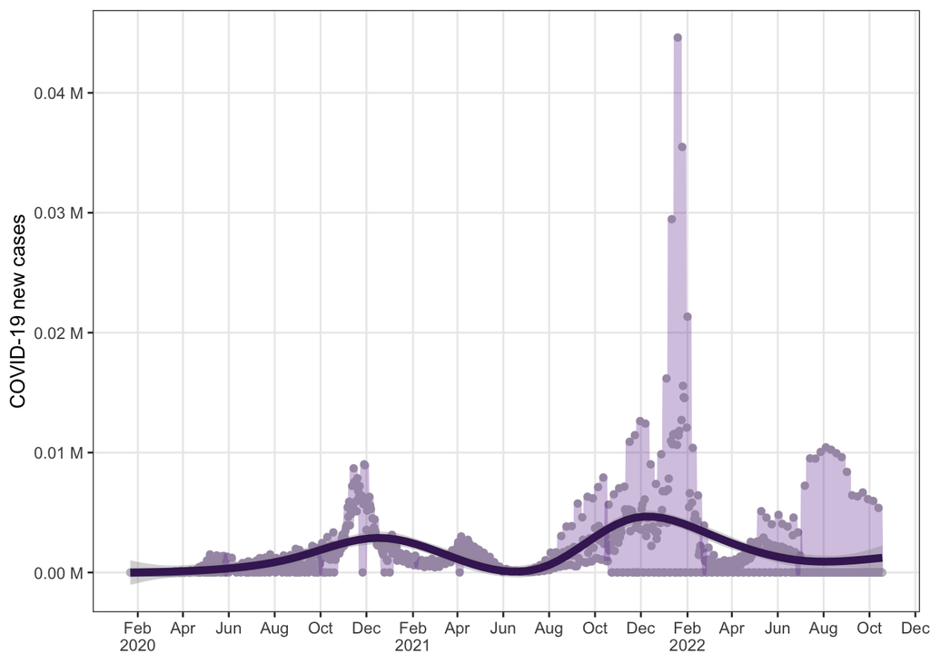

```r
covid_mn %>%
  ggplot(aes(x = as.POSIXct(Date),
             y = new_case)) +
  geom_point(color = "gray") +
  labs(x = NULL, y = "COVID-19 new cases") +
  geom_line(mapping = aes(x = as.POSIXct(Date)),
            linewidth = 2,
            colour = alpha(PrettyCols::prettycols("Purples")[4], 0.3)) +
  geom_smooth(colour = PrettyCols::prettycols("Purples")[1],
              linewidth = 2) +
  scale_y_continuous(labels = scales::label_number(suffix = " M",
                                                   scale = 1e-6)) +
  scale_x_datetime(date_breaks = "2 month",
                   labels = label_date_short()) +
  theme_biosci()
```

We can see that there are some days that no cases were reported, however, it looks like follows the same pattern as the entire United States.

Let’s see what happens if we plot the cumulative number of cases.

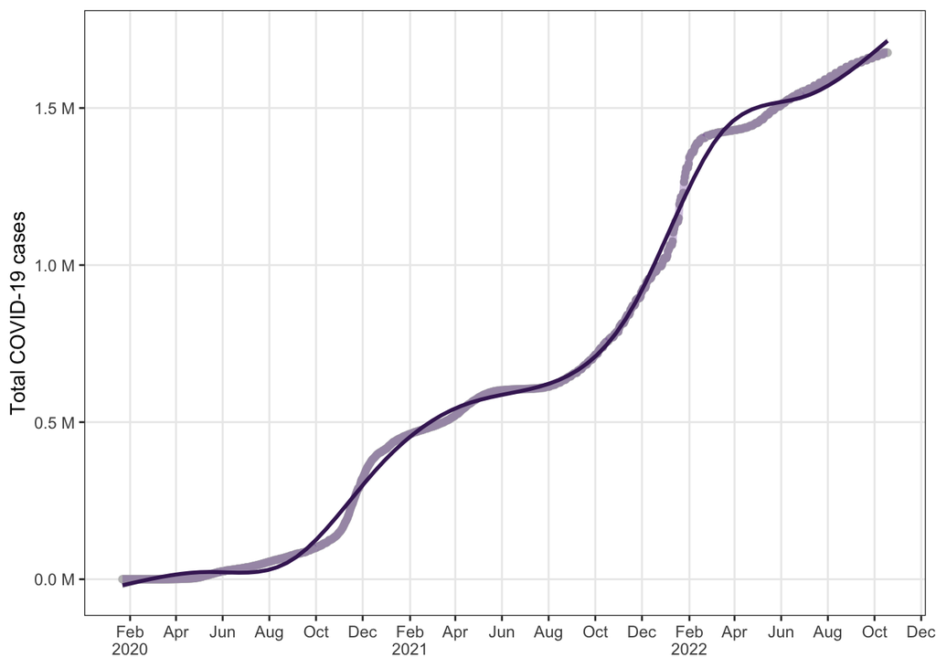

```r
covid_mn %>%
  ggplot(aes(x = as.POSIXct(Date),
             y = tot_cases)) +
  geom_point(color = "gray") +
  labs(x = NULL, y = "Total COVID-19 cases") +
  geom_line(mapping = aes(x = as.POSIXct(Date)),
            linewidth = 2,
            colour = alpha(PrettyCols::prettycols("Purples")[4], 0.3)) +
  geom_smooth(colour = PrettyCols::prettycols("Purples")[1],
              linewidth = 1) +
  scale_y_continuous(labels = scales::label_number(suffix = " M",
                                                   scale = 1e-6)) +
  scale_x_datetime(date_breaks = "2 month", labels = label_date_short()) +
  theme_biosci()
```

It look like the after three years the cumulative number of cases is reaching a plateau.

We can also see the number of deaths caused by COVID-19 in the state of Minnesota.

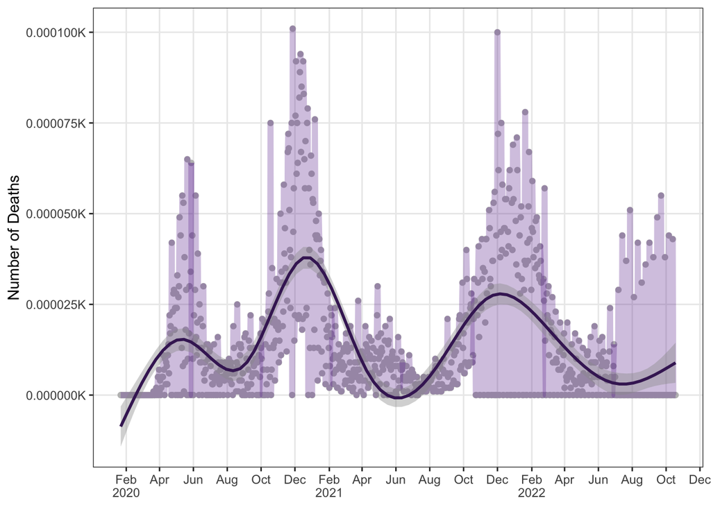

```r
covid_mn %>%
  ggplot(aes(x = as.POSIXct(Date),
             y = abs(new_death))) +
  geom_point(color = "gray") +
  labs(x = NULL, y = "Number of Deaths") +
  geom_line(mapping = aes(x = as.POSIXct(Date)),
            linewidth = 2,
            colour = alpha(PrettyCols::prettycols("Purples")[4], 0.3)) +
  geom_smooth(colour = PrettyCols::prettycols("Purples")[1],
              linewidth = 1) +
  scale_y_continuous(labels = scales::label_number(suffix = "K",
                                                   scale = 1e-6)) +
  scale_x_datetime(date_breaks = "2 month", labels = label_date_short()) +
  theme_biosci()
```

## 3.2 Modeling SIR

Now using the data from the US we will fit the SIR model to predict the changes in the number of Infected cases. The basic idea of the SIR model is, in fact, quite simple. First, we can see that the SIR model is composed of a set of three groups of people or compartments:

1. Those who are healthy but susceptible to the disease (**S**) 😀🫣🤔
2. the infected (**I**) 😱😷🤒
3. the recovered (**R**) 😬🤗 or 😵

Then, these compartments in turn are used to model the dynamics of an outbreak. However, first of all we need to understand a little bit the *Math* behind the scenes. Dr. Seraina Cappelli provided a nice introduction to the math in the last lecture, but if you want to dig a little bit more you can watch this amazing video by Trevor Bazett [The MATH of Epidemics | Intro to the SIR Model](https://www.youtube.com/watch?v=Qrp40ck3WpI) on YouTube. But, if you want to learn more details on this topic, the Book [**Epidemics: models and data using R**](https://www.springer.com/gp/book/9783319974866) by Bjørnstad (2018) can help you.

Anyhow, let’s recap a little bit how the math works. To do that, we need three *differential equations*, one for the change in each group or compartment, where $\beta$ (represents the infection rate) is the parameter that controls the transition between $S$ and $I$ and $\gamma$ (gamma) which controls the transition between $I$ and $R$, and represents the removal or recovery rate.

The first equation indicates that the number of susceptible subjects ($S$) decreases with the number of newly infected subjects. In other words, every new infected subject is the result of the infection rate ($\beta$) times the number of susceptible individuals ($S$) who had a contact with an infected subject ($I$).

$$\frac{dS}{dt} = - \frac{\beta IS}{N}$$

The second equation indicates that the number of infected subjects ($I$) increases as new infected individuals are added to the pool ($\beta IS$) minus the recovered subjects ($\gamma I$), where, $\gamma I$ is the removal rate $\gamma$ times the infected subjects $I$.

$$\frac{dI}{dt} = \frac{\beta IS}{N} - \gamma I$$

Finally, the third equation indicates that the number of recovered subjects $R$ increases with the number of subjects who either recovered or died ($\gamma I$).

$$\frac{dR}{dt} = \gamma I$$

Okay, we are almost there. But first let’s see how an epidemic develops.

- Step zero - An outbreak starts when no subject in the population has anti-bodies, in other words, when $S$ (susceptible subjects) equal the entire population $N$.
- Step one - Once one subject in the population get infected ($I$), this subject change the state from $S$ to $I$. Thus, $S$ decreases by **1** as new $I$ are added to the population.
- Step two - Each $I$ (before recovering 😬 or dying 😵) in turn infect other subjects in the population.
- Step three - The dynamic continues as newly $I$ subjects infect other $S$ subjects in the population before they recover (or died) or until some **Interventions** are applied (e.g., quarantine, wearing masks).
- Step four - Vaccines are developed (**YAY** 👏🎊🎉), so a counteract can be applied to reduce the number of $S$ or to increase the number of $R$.

As we now understand how the $SIR$ model works, we can build an **R function** that allow us to model the dynamic of a disease.

```r
SIR <- function(time, state, parameters) {
  par <- as.list(c(state, parameters))
  with(par, {
    dS <- -Beta * I * S / N # Equation one
    dI <- Beta * I * S / N - Gamma * I # Equation two
    dR <- Gamma * I # Equation three
    list(c(dS, dI, dR))
    })
}
```

Now to fit the $SIR$ model to the data (Minnesota dataset) we need a *solver* and an *optimizer*. Wait, what is a solver? Well, the $SIR$ model is an *Ordinary Differential Equation* (**ODE**), thus, a solver function is needed to help us to solve the equations. We will use the function “**ode**” of the package {**deSolve**} and the “**optim**” function of {**R base**} as an optimizer.

More specifically, in order to solve the equations we need is to minimize the sum of the squared differences ($RSS$) between the number of $I$ subjects (infected) and time $t$–$I(t)$–and the number of predicted cases by our model, i.e., $\hat{I}(t)$:

$$RSS(\beta, \gamma) = \sum_t \big(I(t) - \hat{I}(t) \big)^2$$

Before start solving the $SIR$ model, let’s write another function that allows the $RSS$ estimation.

```r
RSS <- function(parameters) {
  names(parameters) <- c("Beta", "Gamma")
  out <- ode(y = init, times = Days, func = SIR, parms = parameters)
  # the out object includes the SIR function we wrote above
  fit <- out[, 3]
  sum((Infected - fit)^2)
}
```

Okay, we now have almost all information needed to fit our first $SIR$ model. The last information we need is to set of initial values for $N$ (population size), $S$, $I$ and $R$.

```r
# Total population for the State of Minnesota by July 2023
N <- 5737915
```

By observing the trend in the number of cases for MN, we can see that the first date with records of infected subject was in **March 06, 2020** (you can double check to confirm that date), so, let’s set that day as a starting point for our $SIR$ model.

```r
covid_mn %>%
  filter(Date == "2020-03-06")
```

```
        Date month day year state tot_cases conf_cases prob_cases new_case
1 2020-03-06    03  06 2020    MN         1         NA         NA        1
  pnew_case tot_death conf_death prob_death new_death pnew_death
1        NA         0         NA         NA         0         NA
              created_at consent_cases consent_deaths
1 03/26/2020 04:22:39 PM           N/A          Agree
```

Moreover, as more than three years have passed since the pandemic started, the variability in the number of cases is huge, so let’s select the first ~45 days of cases to fit our model and then use the fitted model to predict the dynamics of COVID-19 for the following year.

```r
start_date <- "2020-03-06"
end_date <- "2020-04-20"

# isolating the infected subjects in the state of Minnesota since the start date

Infections <- covid_mn %>%
  filter(Date >= ymd(start_date) & Date <= ymd(end_date))

#Infected2 <- subset(covid_mn, Date >= ymd(start_date) & Date <= ymd(end_date))$new_case
```

Let’s plot this data and see how it looks.

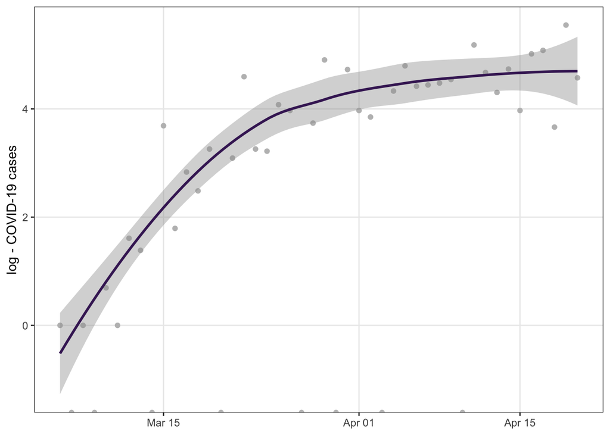

```r
Infections %>%
  ggplot(aes(x = as.POSIXct(Date), y = log(new_case))) +
  geom_point(color = "gray") +
  geom_smooth(colour = PrettyCols::prettycols("Purples")[1],
              linewidth = 1) +
  labs(x = NULL, y = "log - COVID-19 cases") +
  theme_biosci()
```

We can see that the confirmed cases in Minnesota were increasing rapidly since the first case of COVID-19 was reported.

As we now know that the number of $I$ were increasing since the first days of the pandemic, let’s model de dynamic of COVID-19 during that period of time. Why we selected that period of time and not all data? Well, the main reason is that this kind of models are used to explore the first stages of a disease in order to identify if the disease has the potential to become a pandemic and to approximate its reproductive ratio $R_0$.

```r
# ODE does not like tidy format, so we are going to isolate the number of cases in R base.

Infected <- Infections$new_case

Days <- 1:length(Infected) # Number of days since the first case

# Initial values for our SIR model
init <- c(
  S = N - Infected[1], # Susceptible group
  I = Infected[1], # Infected group
  R = 0 # Recovered group.
)
```

Now we can combine all information and run our model. Using the information provided above, we can find the values of $\beta$ and $\gamma$ that give the smallest $RSS$ that represent the best fit to the data. Let’s start exploring with values of **0.5** for each step and constrain those values to an interval from 0 to 1.

You can play with the initial values by changing the **c(0.5, 0.5)** to lower or higher values (e.g., 0.1 or 0.7), but remember, the estimates of $\beta$ and $\gamma$ will change. A nice post that explains in more detail the impact of changing the initial values can be found [HERE](https://blog.ephorie.de/contagiousness-of-covid-19-part-i-improvements-of-mathematical-fitting-guest-post).

```r
Opt <- optim(c(0.5, 0.5),
  RSS,
  method = "L-BFGS-B",
  lower = c(0, 0),
  upper = c(1, 1)
)
```

Check if the model converged.

```r
# optimize with some sensible conditions
Opt$message
```

```
[1] "CONVERGENCE: REL_REDUCTION_OF_F <= FACTR*EPSMCH"
```

```r
# [1] "CONVERGENCE: REL_REDUCTION_OF_F <= FACTR*EPSMCH"
```

Yay! our model show convergence.

From the optimized model we can obtain the $\beta$ and $\gamma$ values, and remember, these values controls for the transition between $S$ (susceptible) and $I$ (infectious) and $I$ and $R$ (recovered), respectively.

```r
Opt_par <- setNames(Opt$par, c("Beta", "Gamma"))

Opt_par
```

```
     Beta     Gamma
0.5582996 0.4417005
```

Now using the fitted $\beta$ and $\gamma$ values, we can see if our model recovers the observed trend in the state of Minnesota for the first two months since the first positive $I$ case was reported.

```r
# get the fitted values from our SIR model
fit_incidence <- data.frame(ode(
  y = init, times = Days,
  func = SIR, parms = Opt_par
))

head(fit_incidence)
```

```
  time       S        I         R
1    1 5737914 1.000000 0.0000000
2    2 5737913 1.123669 0.4684823
3    3 5737913 1.262631 0.9949011
4    4 5737912 1.418779 1.5864213
5    5 5737911 1.594238 2.2510942
6    6 5737910 1.791395 2.9979671
```

```r
tail(fit_incidence)
```

```
   time       S        I        R
41   41 5737411 106.0128 397.8931
42   42 5737348 119.1171 447.5569
43   43 5737278 133.8403 503.3595
44   44 5737199 150.3823 566.0592
45   45 5737110 168.9674 636.5081
46   46 5737009 189.8477 715.6630
```

Let’s plot the estimated $I$ over the first two months. We will use a kind of plot named **semi-log plot**, this plot allow us the read the difference between the expected (fitted) and observed number of confirmed cases over time.

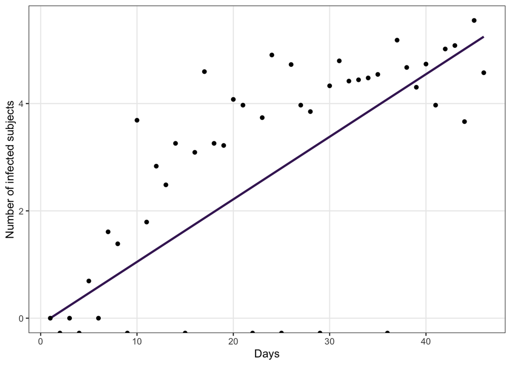

```r
#matplot(fit_incidence$time, fit_incidence$I,
 #       type = "l", log = "y",
  #      xlab = "Days", ylab = "Number of infected subjects",
   #     lwd = 2, lty = 1)

#points(Days, Infected)


fit_incidence %>%
  ggplot(aes(x = time, y = log(I))) +
  geom_smooth(colour = PrettyCols::prettycols("Purples")[1],
              linewidth = 1) +
  geom_point(data = Infections, aes(x = Days, y = log(new_case))) +
  labs(x = "Days", y = "Number of infected subjects") +
  theme_biosci()
```

*How do you feel about that?*

**Answer:** Despite its simplicity, the SIR model can still be used to explore the dynamics of infectious diseases. However, we must exercise great care if we want to use its output to make predictions.

*Do you see any other interested pattern? If so, please explain*

**Answer:** It seems that under the SIR model, the number of infected subjects increases linearly. However, the actual data shows that the number of reported infected cases started to saturate after 20 days.

## 3.3 Reproduction number $R_0$ (R naught)

Although our SIR model does not fit the observed data accurately, we can still use it to estimate the basic reproduction number $R_0$ (AKA reproductive ratio). The $R_0$ give us an approximate estimation of how many $S$ subjects get infected by a sick subject ($I$) on average–i.e., the transmission probability per contact (Ashby & Best, 2021). Importantly, $R_0$ is not a fixed value and can vary over time and between populations. To calculate $R_0$ we just need to obtain the ratio between $\beta$ and $\gamma$:

$$R_0 = \frac{\beta}{\gamma}$$

**On the derivation of the back-of-the-envelope $R_0$ by Elizabeth Borer**

It arises from the concept of “force of infection” which is the rate that susceptibles get infected. This is broadly a function of host mortality and the infectiousness of a pathogen. There was a lot of work on the math of this in the 1950s-1980s (that I have not spent the time to fully follow through), but the relationships that emerge are relatively simple. One key one that e.g., Anderson and May use a lot comes from Muench (1950s math) and Dietz (1993) [attached](https://www.dropbox.com/s/vcexeah6npcfewp/Dietz-1993-StatMethodsMedResearch-estimating%20R0.pdf?dl=0). In this case, force of infection has been described as $\mu(R_0 - 1)$ [where $\mu$ is the host background mortality rate]. They were originally using this to estimate the average age of infection, but you can turn this around to estimate $R_0$, too.

Life expectancy can be estimated as $\mu^-1$ (inverse function of mortality) — or if we want to be even more simplistic (as in this lecture), we can assume a stable host population and estimate life expectancy just as a constant, $L$. Then, just rearranging the stuff these guys did on average age of infection as a function of $R_0$ and life expectancy, you can use the host values to estimate the $R_0$.

$$A = \frac{(\mu^-1)}{R_0-1}$$
From the early math in Muench & Dietz Substitute in the constant, $L$, as an estimate of $\mu^-1$

$$A = \frac{L}{R_0-1}$$
Rearrange and you get

One more time

$$R_0 = 1 + \frac{L}{A}$$

There are a ton of assumptions in each of these steps (pathogen is increasing, complete mixing, no host variation, etc), but this is all basically derived from the original **SIR** models via relationships describing force of infection.

```r
R0 <- setNames(Opt_par["Beta"] / Opt_par["Gamma"], "R0")

round(R0, 3)
```

```
   R0
1.264
```

The estimated $R_0$ is 1.264 which suggests that for every sick subject 1.3 subjects can get infected by COVID-19. This value is lower when compared to other diseases and even lower than the estimated $R_0$ for COVID-19 in the literature that ranges between 2.5 and 3. One potential explanation for this low $R_0$ can be due the fact the first 45 days, the number of observed cases were very low when compared with the large population size ($N$) in the state of Minnesota.

Another reason could be that the number of reported cases of COVID-19 in US are not true, in other words, the reported cases are lower than the true cases (Wu et al., 2020). This is critical when we are constructing any kind of model, as potentially we would be facing the **GIGO** metaphor–*garbage-in, garbage-out*–that indicates that if the data used in a model are not reliable, then the results are not useful. In other words, you can be using the best mathematical model ever constructed, but if your data is not reliable or coherent, then your results are not useful (are garbage).

## 3.4 Evaluating the outbreak under no intervention

To fit our model we used data within two months since the first reported case, now let’s explore what would it happen if no public intervention (i.e., quarantine) was applied. Here, using the fitted model we will extrapolate up to 350 days.

```r
times <- 1:350 # time in days

fit_350 <- data.frame(ode(
  y = init, times = times,
  func = SIR, parms = Opt_par))

head(fit_350)
```

```
  time       S        I         R
1    1 5737914 1.000000 0.0000000
2    2 5737913 1.123669 0.4684823
3    3 5737913 1.262631 0.9949011
4    4 5737912 1.418779 1.5864213
5    5 5737911 1.594238 2.2510942
6    6 5737910 1.791395 2.9979671
```

```r
tail(fit_350)
```

```
    time       S            I       R
345  345 3520955 6.158620e-05 2216960
346  346 3520955 5.577526e-05 2216960
347  347 3520955 5.051262e-05 2216960
348  348 3520955 4.574652e-05 2216960
349  349 3520955 4.143013e-05 2216960
350  350 3520955 3.752101e-05 2216960
```

To better explore the data, let’s make some figures that allow us to see what would happened the first 350 days of the pandemic in the state of Minnesota in a hypothetical case of no intervention.

```r
cols <- 1:3 # colors: black = susceptible, red = infected and green = recovered
```

Now, let’s plot the output.

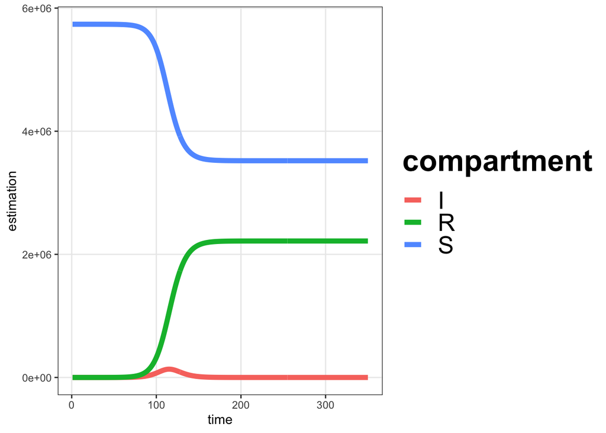

```r
#matplot(fit_350$time, fit_350[, 2:4], type = "l",
 #       xlab = "Days since infection", ylab = "Number of subjects",
  #      lwd = 2, lty = 1, col = cols)

#legend("left", c("Susceptible", "Infected", "Recovered"),
 #      lty = 1, lwd = 2, col = cols, inset = 0.05)

## GGPLOT format
tt <- fit_350 %>%
  pivot_longer(!time, values_to = "estimation", names_to = "compartment")

tt %>%
  ggplot(aes(x = time, y = estimation,
             group = compartment,
             color = compartment)) +
  geom_line(linewidth = 2) +
  theme_biosci()
```

Same figure but in log scale and adding the observed cases

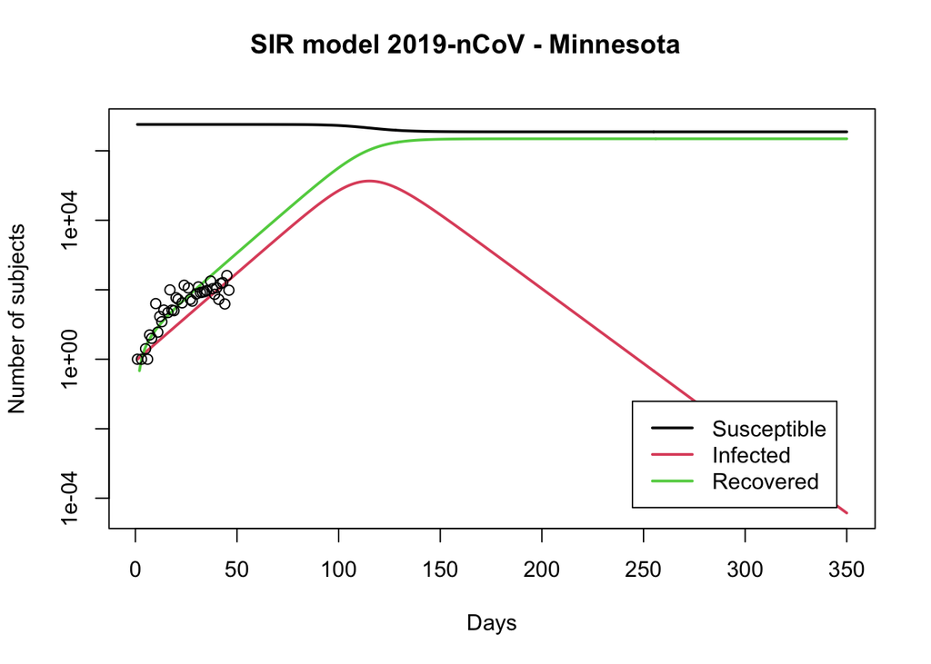

```r
matplot(fit_350$time, fit_350[ , 2:4],
        type = "l",
        xlab = "Days",
        ylab = "Number of subjects",
        lwd = 2,
        lty = 1,
        col = cols,
        log = "y")
## Warning in xy.coords(x, y, xlabel, ylabel, log = log): 1 y value <= 0
## omitted from logarithmic plot
points(Days, Infected)

legend("bottomright", c("Susceptible", "Infected", "Recovered"),
       lty = 1, lwd = 2, col = cols, inset = 0.05)

title("SIR model 2019-nCoV - Minnesota", outer = TRUE, line = -2)
```

*How do you feel about that?*

**Answer:** SIR model projections are visually appealing but can’t recover the actual data accurately.

*Please explain the trend of each compartment in a temporal way?*

**Answer:** Despite the SIR models not being accurate enough to predict the dynamics of infectious diseases, we can still use the model projections to have a scenario in which no intervention (e.g., quarantine) is applied. Under this scenario of no intervention, the number of infected subjects increased linearly until day 115 (I = 134881) after the beginning of the pandemic. Then, there is a continuous decline in the number of infected subjects. The number of recovered/death cases also increases linearly until day 145 (R = 2110042). Then, the number of R subjects continues increasing but at lower numbers, which gives an impression of saturation. Finally, the number of susceptible (S) cases has been steadily declining but slowly declining over time. It has changed drastically as the number of R subjects has increased.

## 3.5 Additional summary statistics

Using the fitted model we can also estimate some additional statistics that could help us to better understand the dynamics of a pandemic:

- Peak of the pandemic
- Fatality rate

### 3.5.1 Peak of the pandemic

```r
# Peak of the pandemic for the first 45 days
fit_incidence[fit_incidence$I == max(fit_incidence$I), c("time", "I")]
```

```
   time        I
46   46 189.8477
```

### 3.5.2 Fatality rate

```r
max(fit_incidence$I) * 0.02 # Assuming 2% of fatality rate
```

```
[1] 3.796953
```

# 4 The challenge

The challenge for this assignment is to repeat the process by selecting other state in the United States and discuss if the $R_0$ obtained differ to the obtained for the state of Minnesota.

Happy coding!

## References

Ashby, B., & Best, A. (2021). Herd immunity. *Current Biology*, *31*(4), R174–R177. https://doi.org/10.1016/j.cub.2021.01.006

Bartsch, S. M., O’Shea, K. J., Ferguson, M. C., Bottazzi, M. E., Wedlock, P. T., Strych, U., McKinnell, J. A., Siegmund, S. S., Cox, S. N., Hotez, P. J., & Lee, B. Y. (2020). Vaccine efficacy needed for a COVID-19 coronavirus vaccine to prevent or stop an epidemic as the sole intervention. *American Journal of Preventive Medicine*, *59*(4), 493–503. https://doi.org/10.1016/j.amepre.2020.06.011

Bjørnstad, O. N. (2018). *Epidemics: Models and data using r*. Springer International Publishing. https://doi.org/10.1007/978-3-319-97487-3

Dietz, K. (1993). The estimation of the basic reproduction number for infectious diseases. *Statistical Methods in Medical Research*, *2*(1), 23–41. https://doi.org/10.1177/096228029300200103

Revell, L. J. (2021). covid19.Explorer: A web application and R package to explore United States COVID-19 data. *PeerJ*, *9*, e11489. https://doi.org/10.7717/peerj.11489

Wu, S. L., Mertens, A. N., Crider, Y. S., Nguyen, A., Pokpongkiat, N. N., Djajadi, S., Seth, A., Hsiang, M. S., Colford, J. M., Reingold, A., Arnold, B. F., Hubbard, A., & Benjamin-Chung, J. (2020). Substantial underestimation of SARS-CoV-2 infection in the united states. *Nature Communications*, *11*(1), 4507. https://doi.org/10.1038/s41467-020-18272-4